# Clustering

#### 0.6.2.4 Computing PAM

```r
Pam=  pam(data, 2) #computes PAM algorithm with k = 2
Pam
```

```
## Medoids:
##            ID     Murder    Assault   UrbanPop       Rape
## New Mexico 31  0.8292944  1.3708088  0.3081225  1.1603196
## Nebraska   27 -0.8008247 -0.8250772 -0.2445636 -0.5052109
## Clustering vector:
##        Alabama         Alaska        Arizona       Arkansas     California
##              1              1              1              2              1
##       Colorado    Connecticut       Delaware        Florida        Georgia
##              1              2              2              1              1
##         Hawaii          Idaho       Illinois        Indiana           Iowa
##              2              2              1              2              2
##         Kansas       Kentucky      Louisiana          Maine       Maryland
##              2              2              1              2              1
##  Massachusetts       Michigan      Minnesota    Mississippi       Missouri
##              2              1              2              1              1
##        Montana       Nebraska         Nevada  New Hampshire     New Jersey
##              2              2              1              2              2
##     New Mexico       New York North Carolina   North Dakota           Ohio
##              1              1              1              2              2
##       Oklahoma         Oregon   Pennsylvania   Rhode Island South Carolina
##              2              2              2              2              1
##   South Dakota      Tennessee          Texas           Utah        Vermont
##              2              1              1              2              2
##       Virginia     Washington  West Virginia      Wisconsin        Wyoming
##              2              2              2              2              2
## Objective function:
##    build     swap
## 1.441358 1.368969
##
## Available components:
##  [1] "medoids"    "id.med"     "clustering" "objective"  "isolation"
##  [6] "clusinfo"   "silinfo"    "diss"       "call"       "data"
```

```
The printed output shows:

- the cluster medoids: a matrix, which rows are the medoids and columns are variables

- the clustering vector: A vector of integers (from 1:k) indicating the cluster to which each point is allocated
```

If we want to add the point classifications to the original data:

```r
dd= cbind(USArrests, cluster = Pam$cluster)
head(dd, n = 3)
```

```
##         Murder Assault UrbanPop Rape cluster
## Alabama   13.2     236       58 21.2       1
## Alaska    10.0     263       48 44.5       1
## Arizona    8.1     294       80 31.0       1
```

#### 0.6.2.5 Visualizing PAM clusters

To visualize the partitioning results, we’ll use the function `fviz_cluster()` [`factoextra` package].

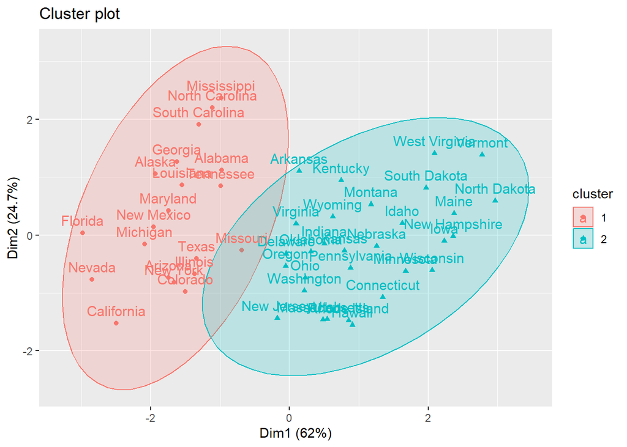

```r
fviz_cluster(Pam,data,ellipse.type = "norm")
```

Note that, for large data sets, pam() may need too much memory or too much computation time. In this case, the function clara() is preferable. This should not be a problem for modern computers.

Note that there is a variant of PAM named CLARA (Clustering Large Applications, (Kaufman and Rousseeuw 1990)) which is used for analyzing large data sets. It is an extension to k-medoids (PAM) methods to deal with data containing a large number of objects (more than several thousand observations) in order to reduce computing time and RAM storage problem. This is achieved using the sampling approach.

Instead of finding medoids for the entire data set, CLARA considers a small sample of the data with fixed size (sampsize) and applies the PAM algorithm to generate an optimal set of medoids for the sample. The quality of resulting medoids is measured by the average dissimilarity between every object in the entire data set and the medoid of its cluster, defined as the cost function.

CLARA repeats the sampling and clustering processes a pre-specified number of times in order to minimize the sampling bias. The final clustering results correspond to the set of medoids with the minimal cost.

## 0.7 Agglomerative Hierarchical Clustering

The agglomerative clustering is the most common type of hierarchical clustering used to group objects in clusters based on their similarity. It works in a “bottom-up” manner. That is, - each object is initially considered as a single-element cluster (leaf).

- At each step of the algorithm, the two clusters that are the most similar are combined into a new bigger cluster (nodes).

-This procedure is iterated until all points are member of just one single big cluster (root).

**The steps to agglomerative hierarchical clustering are:**

1. Preparing the data (*standardize the variables*)
2. Computing (dis)similarity information between every pair of objects in the data set.
3. sing linkage function to group objects into hierarchical cluster tree, based on the distance information generated at step 1. Objects/clusters that are in close proximity are linked together using the linkage function.
4. Determining where to cut the hierarchical tree into clusters. This creates a partition of the data.

**Similarity measures**

There are many methods to calculate the (dis)similarity information, including **Euclidean** and **manhattan distances**. In R software, we can use the function `dist()` to compute the distance between every pair of object in a data set, which is known as a distance or dissimilarity matrix.

**Linkage**

The linkage function takes the distance information, returned by the function dist(), and groups pairs of objects into clusters based on their similarity. Next, these newly formed clusters are linked to each other to create bigger clusters. This process is iterated until all the objects in the original data set are linked together in a hierarchical tree.

There are many cluster agglomeration methods (i.e, linkage methods). The most common linkage methods are: - *Maximum or complete linkage*

- *Minimum or single linkage*
- *Mean or average linkage*
- *Centroid linkage*
- *Ward’s minimum variance method:* It minimizes the total within-cluster variance. At each step the pair of clusters with minimum between-cluster distance are merged.

Complete linkage and Ward’s method are generally preferred.

### 0.7.1 Computing Agglomerative Hierarchical Clustering

the R base function `hclust()` can be used to create the hierarchical tree. Alternatively, the package `cluster` makes it easy to perform cluster analysis in R. It provides the function `agnes()` and `diana()` for computing agglomerative and divisive clustering, respectively.

#### 0.7.1.1 Data

`USArrests` Dataset

#### 0.7.1.2 Required R packages and functions

The function `hclust()` [`base` package] is used to compute **Hierarchical Clustering**.

Dendrograms correspond to the graphical representation of the hierarchical tree generated by the function `hclust()`.

Dendrogram can be produced in R using the base function `plot()`. We can also use `fviz_dend()`[ in `factoextra` package] to produce a beautiful dendrogram.

```r
library(cluster)
library(factoextra)
```

#### 0.7.1.3 Calculating dissimilarity matrix

```r
data= scale(USArrests)

res.dist= dist(data, method = "euclidean")

dim(as.matrix(res.dist))
```

```
## [1] 50 50
```

```r
round(as.matrix(res.dist)[1:10,1:10],2)
```

```
##             Alabama Alaska Arizona Arkansas California Colorado Connecticut
## Alabama        0.00   2.70    2.29     1.29       3.26     2.65        3.22
## Alaska         2.70   0.00    2.70     2.83       3.01     2.33        4.74
## Arizona        2.29   2.70    0.00     2.72       1.31     1.37        3.26
## Arkansas       1.29   2.83    2.72     0.00       3.76     2.83        2.61
## California     3.26   3.01    1.31     3.76       0.00     1.29        4.07
## Colorado       2.65   2.33    1.37     2.83       1.29     0.00        3.33
## Connecticut    3.22   4.74    3.26     2.61       4.07     3.33        0.00
## Delaware       2.02   3.62    1.91     1.80       3.07     2.55        1.76
## Florida        2.30   3.00    1.75     3.37       2.03     2.45        4.47
## Georgia        1.13   2.82    2.79     2.21       3.38     2.86        3.97
##             Delaware Florida Georgia
## Alabama         2.02    2.30    1.13
## Alaska          3.62    3.00    2.82
## Arizona         1.91    1.75    2.79
## Arkansas        1.80    3.37    2.21
## California      3.07    2.03    3.38
## Colorado        2.55    2.45    2.86
## Connecticut     1.76    4.47    3.97
## Delaware        0.00    3.06    2.98
## Florida         3.06    0.00    2.18
## Georgia         2.98    2.18    0.00
```

#### 0.7.1.4 Computing Agglomerative Hierarchical Clustering with Linkage

```r
Hc= hclust(d = res.dist, method = "ward.D2")
```

Note that, the function `hcut()`[in `factoextra` package] can also be used to Computes hierarchical clustering (hclust, agnes, diana) and cut the tree into k clusters.

#### 0.7.1.5 Dendogram

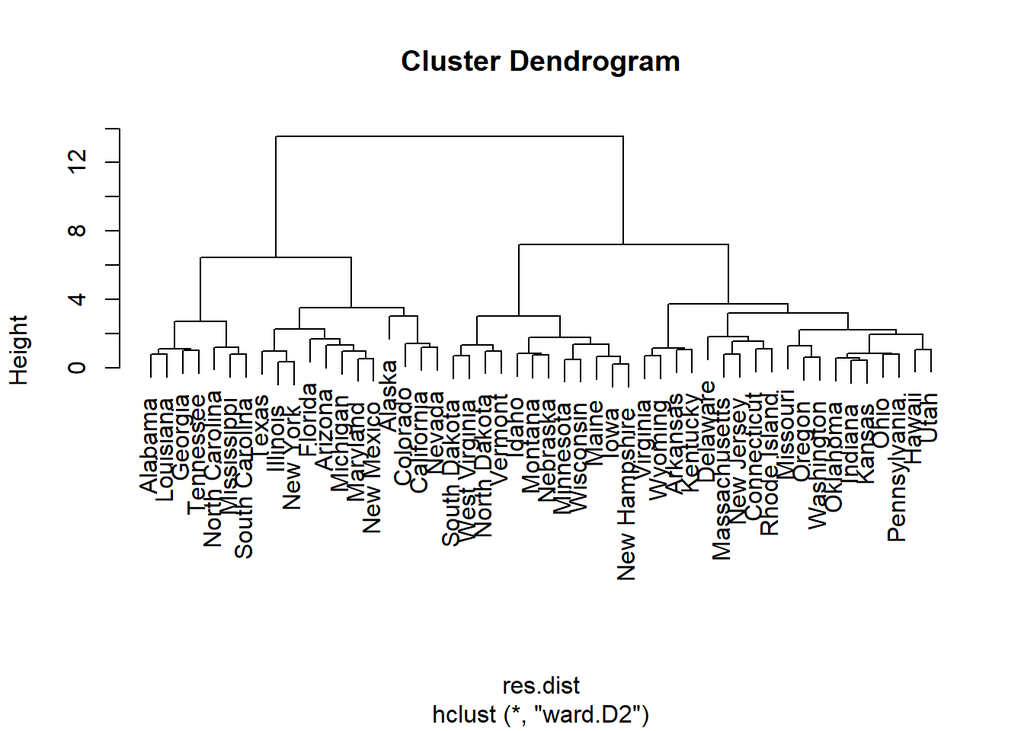

```r
plot(Hc)
```

Similarly by using `factoextra` package:

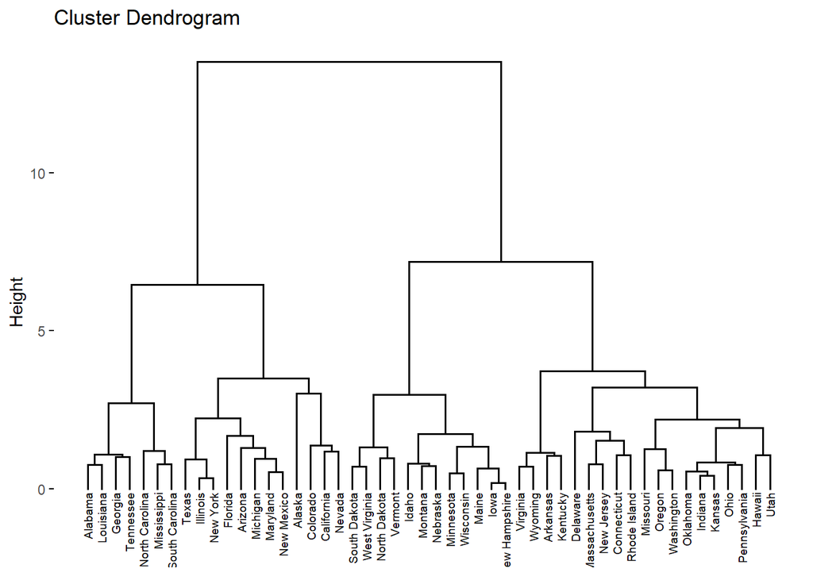

```r
library("factoextra")
fviz_dend(Hc, cex = 0.5)
```

#### 0.7.1.6 Verify the cluster tree

After linking the objects in a data set into a hierarchical cluster tree, we usually want to assess that the distances (i.e., heights) in the tree reflect the original distances accurately.

- One way to measure this, is to compute the correlation between the **cophenetic distances** and the **original distance** data generated by the `dist()` function.
- If the clustering is valid, the linking of objects in the cluster tree should have a strong correlation with the distances between objects in the original distance matrix.
- The closer the value of the correlation coefficient is to 1, the more accurately the clustering solution reflects your data. Values above 0.75 are felt to be good.
- The R base function `cophenetic()` can be used to compute the **cophenetic distances** for hierarchical clustering.

```r
# Compute cophentic distance
coph= cophenetic(Hc)

# Correlation between cophenetic distance and  the original distance
cor(coph, res.dist)
```

```
## [1] 0.6975266
```

Execute the `hclust()` function again using the average linkage method. Next, call `cophenetic()` to evaluate the clustering solution.

```r
Hc2= hclust(res.dist, method = "average")

cor(res.dist, cophenetic(Hc2))
```

```
## [1] 0.7180382
```

The correlation coefficient shows that using a different linkage method creates a tree that represents the original distances slightly better.

#### 0.7.1.7 Cut the dendrogram into different groups

One of the problems with hierarchical clustering is that, it does not tell us how many clusters there are, or where to cut the dendrogram to form clusters.

- We can cut the hierarchical tree at a given height in order to partition your data into clusters.
- The R base function `cutree()` can be used to cut a tree, generated by the `hclust()` function, into several groups either by specifying the desired number of groups or the cut height.
- It returns a vector containing the cluster number of each observation.

```r
# Cut tree into 4 groups
grp= cutree(Hc, k = 4)
head(grp, n = 4)
```

```
##  Alabama   Alaska  Arizona Arkansas
##        1        2        2        3
```

```r
# Number of members in each cluster
table(grp)
```

```
## grp
##  1  2  3  4
##  7 12 19 12
```

```r
# Get the names for the members of cluster 1
rownames(data)[grp == 1]
```

```
## [1] "Alabama"        "Georgia"        "Louisiana"      "Mississippi"
## [5] "North Carolina" "South Carolina" "Tennessee"
```

The result of the cuts can be visualized easily using the function fviz_dend() [in factoextra]:

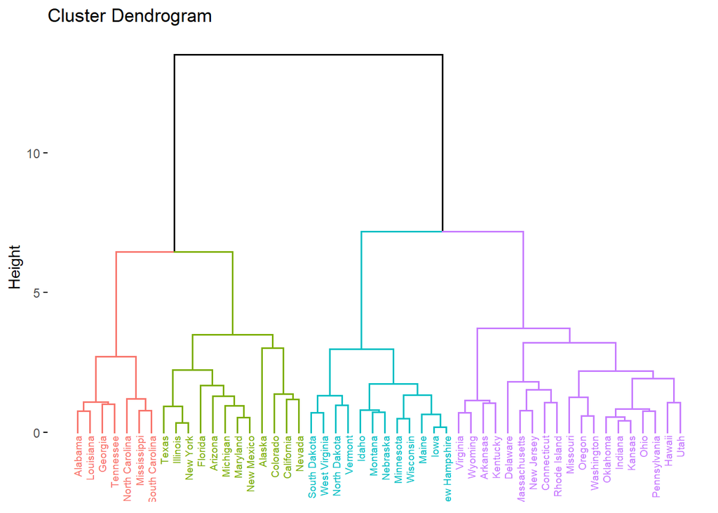

```r
fviz_dend(Hc, cex = 0.5, k = 4, color_labels_by_k = TRUE)
```

Using the function `fviz_cluster()` [in `factoextra`], we can also visualize the result in a scatter plot, but note that, this function cannot be applied on the base package function `hclust()` generated object; for that we will apply `hcut()` function [from `factoextra`] for performing hierarchical clustering. Observations are represented by points in the plot, using principal components. A frame is drawn around each cluster.

```r
hc.cut= hcut(data, k = 4, hc_method = "ward.D2")
hc.cut
```

```
##
## Call:
## stats::hclust(d = x, method = hc_method)
##
## Cluster method   : ward.D2
## Distance         : euclidean
## Number of objects: 50
```

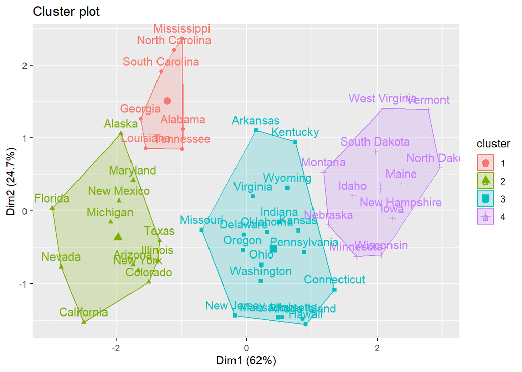

```r
fviz_cluster(hc.cut, ellipse.type = "convex",show.clust.cent=T,geom = c("point", "text") )
```

#### 0.7.1.8 Cluster R package

As discussed earlyar, The R package `cluster` makes it easy to perform cluster analysis in R. The function `agnes()` and `diana()` functions perform all the necessary steps for you. We don’t need to execute the `scale()`, `dist()` and `hclust()` function separately.

```r
library("cluster")

# Agglomerative Nesting (Hierarchical Clustering)

agnes=  agnes(x = USArrests, # data matrix
              stand = TRUE, # Standardize the data
              metric = "euclidean", # metric for distance matrix
              method = "ward" # Linkage method
             )

# DIvisive ANAlysis Clustering

diana= diana(x = USArrests, # data matrix
             stand = TRUE, # standardize the data
             metric = "euclidean" # metric for distance matrix
            )
```

After running `agnes()` and `diana()`, you can use the function `fviz_dend()`[in `factoextra`] to visualize the output:

```r
fviz_dend(res.agnes, cex = 0.6, k = 4)
```

[output not shown]

## 0.8 Divisive Hierarchical Clustering

- The divisive hierarchical clustering, is the inverse of agglomerative clustering.
- It starts by including all objects in a single large cluster.
- At each step of iteration, the most heterogeneous cluster is divided into two.
- The process is iterated until all objects are in their own cluster.

**Recall that**, divisive clustering is good at identifying large clusters while agglomerative clustering is good at identifying small clusters.

### 0.8.1 Computation

The R function `diana()` [`cluster` package] can be used to compute divisive clustering. It returns an object of class `diana` (see ?`diana.object`) which has also methods for the functions: `print()`, `summary()`, `plot()`, `pltree()`, `as.dendrogram()`, `as.hclust()` and `cutree()`.

The output can be visualized as dendrograms using the function `fviz_dend() [`factoextra` package]. For example:

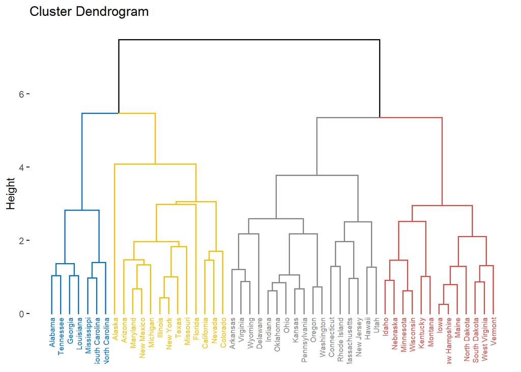

```r
# Compute diana()
library(cluster)
res.diana <- diana(USArrests, stand = TRUE)

# Plot the dendrogram
library(factoextra)
fviz_dend(res.diana, cex = 0.5,
          k = 4, # Cut in four groups
          palette = "jco" # Color palette
          )
```

## 0.9 Comparing Cluster Dendrograms

Now, we will see how to compare cluster dendrograms in R using the 1dendextend` R package. Suppose we have computed two dendrograms by computing hierarchical clustering (HC) using two different linkage methods (“average” and “ward.D2”).

### 0.9.1 Data

```r
data= scale(USArrests)

# working with a small random subset of the data set with 10 observations among the 50 observations.
set.seed(123)
id= sample(1:50, 10)
data= data[id,]
```

```r
library(dendextend)
library(dplyr)
# Compute distance matrix
res.dist= dist(data, method = "euclidean")

# Compute 2 hierarchical clusterings
hc1= hclust(res.dist, method = "average")
hc2= hclust(res.dist, method = "ward.D2")

# Create two dendrograms
dend1= as.dendrogram (hc1)
dend2= as.dendrogram (hc2)

# Create a list to hold dendrograms
dend_list= dendlist(dend1, dend2)
```

#### 0.9.1.1 Visual comparison of two dendrograms

To visually compare two dendrograms, we’ll use the following R functions [`dendextend` package]:

- `untangle()`: finds the best layout to align dendrogram lists, using heuristic methods
- `tanglegram()`: plots the two dendrograms, side by side, with their labels connected by lines.
- `entanglement()`: computes the quality of the alignment of the two trees. Entanglement is a measure between 1 (full entanglement) and 0 (no entanglement). A lower entanglement coefficient corresponds to a good alignment.

Draw a tanglegram:

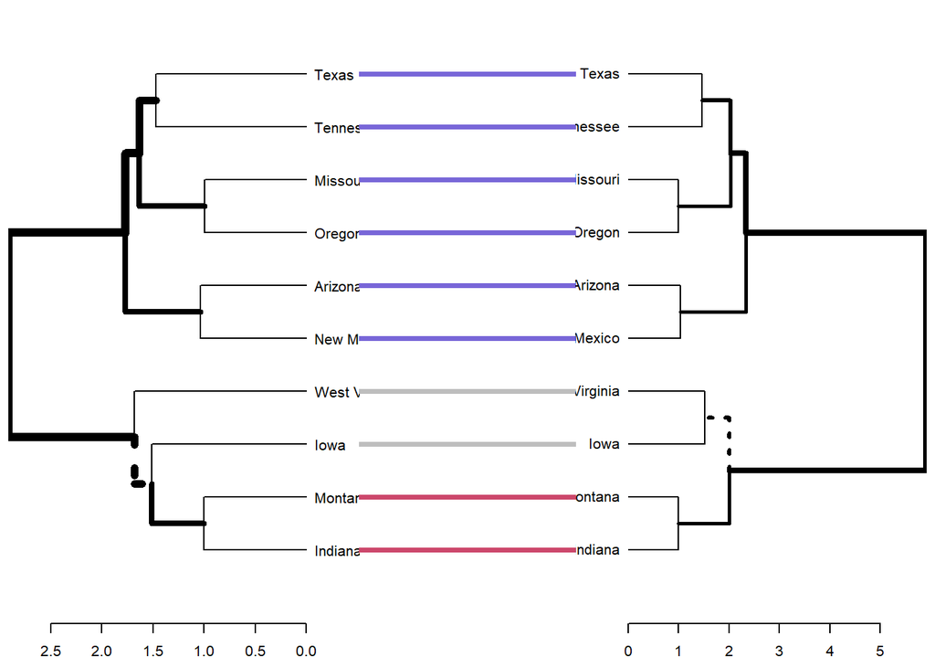

```r
# Align and plot two dendrograms side by side
dendlist(dend1, dend2) %>%
  untangle(method = "step1side") %>% # Find the best alignment layout
  tanglegram()                       # Draw the two dendrograms
```

```r
# Compute alignment quality. Lower value = good alignment quality
dendlist(dend1, dend2) %>%
  untangle(method = "step1side") %>% # Find the best alignment layout
  entanglement()                     # Alignment quality
```

```
## [1] 0
```

#### 0.9.1.2 Correlation matrix between a list of dendrogams

- The function `cor.dendlist()` is used to compute “Baker” or “Cophenetic” correlation matrix between a list of trees.
- The value can range between -1 to 1. With near 0 values meaning that the two trees are not statistically similar.

```r
# Cophenetic correlation matrix
cor.dendlist(dend_list, method = "cophenetic")
```

```
##           [,1]      [,2]
## [1,] 1.0000000 0.9925544
## [2,] 0.9925544 1.0000000
```

```r
# Baker correlation matrix
cor.dendlist(dend_list, method = "baker")
```

```
##           [,1]      [,2]
## [1,] 1.0000000 0.9895528
## [2,] 0.9895528 1.0000000
```

The correlation between two trees can be also computed as follow:

```r
# Cophenetic correlation coefficient
cor_cophenetic(dend1, dend2)
```

```
## [1] 0.9925544
```

```r
# Baker correlation coefficient
cor_bakers_gamma(dend1, dend2)
```

```
## [1] 0.9895528
```

It’s also possible to compare simultaneously multiple dendrograms:

```r
# Create multiple dendrograms by chaining
dend1= data %>% dist %>% hclust("complete") %>% as.dendrogram
dend2= data %>% dist %>% hclust("single") %>% as.dendrogram
dend3= data %>% dist %>% hclust("average") %>% as.dendrogram
dend4= data %>% dist %>% hclust("centroid") %>% as.dendrogram

# Compute correlation matrix
dend_list= dendlist("Complete" = dend1, "Single" = dend2,
                    "Average" = dend3, "Centroid" = dend4)

cors= cor.dendlist(dend_list)

# Print correlation matrix
round(cors, 2)
```

```
##          Complete Single Average Centroid
## Complete     1.00   0.46    0.45     0.30
## Single       0.46   1.00    0.23     0.17
## Average      0.45   0.23    1.00     0.31
## Centroid     0.30   0.17    0.31     1.00
```

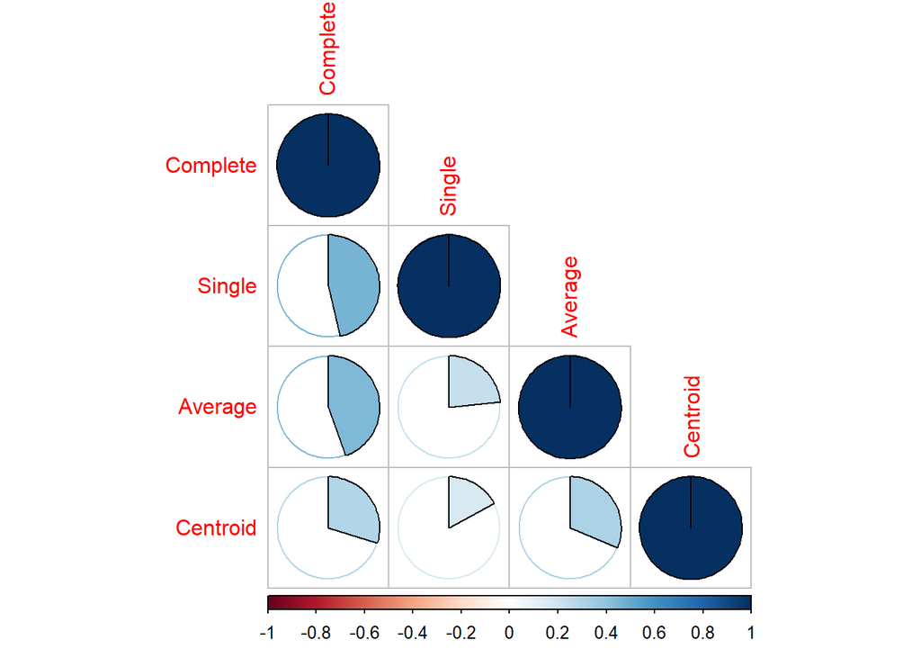

```r
# Visualize the correlation matrix using corrplot package
library(corrplot)
corrplot(cors, "pie", "lower")
```

## 0.10 Computing P-value for Hierarchical Clustering

Clusters can be found in a data set by chance due to clustering noise or sampling error. The R package `pvclust` (Suzuki and Shimodaira 2015) which uses bootstrap resampling techniques to compute p-value for each hierarchical clusters.

The Algorithm for computing P-Values are:

1. Generated thousands of bootstrap samples by randomly sampling elements of the data.
2. Compute hierarchical clustering on each bootstrap copy.
3. For each cluster:
   1. compute the **bootstrap probability (BP)** value which corresponds to the frequency that the cluster is identified in bootstrap copies.
   2. Compute the **approximately unbiased (AU)** probability values (p-values) by multiscale bootstrap resampling.

Clusters with AU >= 95% are considered to be strongly supported by data.

The function `pvclust()` can be used as follow:

```r
pvclust(data, method.hclust = "average",
        method.dist = "correlation", nboot = 1000)
```

```
--------------------------------------------------------------------------------------------------------------
data: numeric data matrix or data frame.
--------------------------------------------------------------------------------------------------------------
method.hclust: the agglomerative method used in hierarchical clustering. Possible values are one of “average”,
               “ward”, “single”, “complete”,“mcquitty”, “median” or “centroid”. The default is “average”.
               See method argument in ?hclust.
--------------------------------------------------------------------------------------------------------------
method.dist: the distance measure to be used. Possible values are one of “correlation”, “uncentered”,
             “abscor” or those which are allowed for method argument in dist() function, such
             “euclidean” and “manhattan”.
--------------------------------------------------------------------------------------------------------------
nboot: the number of bootstrap replications. The default is 1000.
--------------------------------------------------------------------------------------------------------------
iseed: an integrer for random seeds. Use iseed argument to achieve reproducible results.
--------------------------------------------------------------------------------------------------------------
```

The function `pvclust()` returns an object of class *pvclust* containing many elements including *hclust* which contains hierarchical clustering result for the original data generated by the function `hclust()`.

## 0.11 Hierarchical K-Means Clustering: Optimize Clusters

**K-means** represents one of the most popular clustering algorithm. However, it has some limitations:

- it requires the user to specify the number of clusters in advance and selects initial centroids randomly.
- The final k-means clustering solution is very sensitive to this initial random selection of cluster centers.
- The result might be (slightly) different each time you compute k-means.

### 0.11.1 Algorithm

The algorithm is summarized as follow:

1. Compute hierarchical clustering and cut the tree into k-clusters.
2. Compute the center (i.e the mean) of each cluster.
3. Compute k-means by using the set of cluster centers (defined in step 2) as the initial cluster centers.

### 0.11.2 Computation

The R function `hkmeans()` [in `factoextra` package], provides an easy solution to compute the **hierarchical k-means clustering**.

```r
# Compute hierarchical k-means clustering
#library(factoextra)

data= scale(USArrests)

hk= hkmeans(data, 4)
# Elements returned by hkmeans()
names(hk)
```

```
##  [1] "cluster"      "centers"      "totss"        "withinss"     "tot.withinss"
##  [6] "betweenss"    "size"         "iter"         "ifault"       "data"
## [11] "hclust"
```

To print all the results:

```r
hk
```

```
## Hierarchical K-means clustering with 4 clusters of sizes 8, 13, 16, 13
##
## Cluster means:
##       Murder    Assault   UrbanPop        Rape
## 1  1.4118898  0.8743346 -0.8145211  0.01927104
## 2  0.6950701  1.0394414  0.7226370  1.27693964
## 3 -0.4894375 -0.3826001  0.5758298 -0.26165379
## 4 -0.9615407 -1.1066010 -0.9301069 -0.96676331
##
## Clustering vector:
##        Alabama         Alaska        Arizona       Arkansas     California
##              1              2              2              1              2
##       Colorado    Connecticut       Delaware        Florida        Georgia
##              2              3              3              2              1
##         Hawaii          Idaho       Illinois        Indiana           Iowa
##              3              4              2              3              4
##         Kansas       Kentucky      Louisiana          Maine       Maryland
##              3              4              1              4              2
##  Massachusetts       Michigan      Minnesota    Mississippi       Missouri
##              3              2              4              1              2
##        Montana       Nebraska         Nevada  New Hampshire     New Jersey
##              4              4              2              4              3
##     New Mexico       New York North Carolina   North Dakota           Ohio
##              2              2              1              4              3
##       Oklahoma         Oregon   Pennsylvania   Rhode Island South Carolina
##              3              3              3              3              1
##   South Dakota      Tennessee          Texas           Utah        Vermont
##              4              1              2              3              4
##       Virginia     Washington  West Virginia      Wisconsin        Wyoming
##              3              3              4              4              3
##
## Within cluster sum of squares by cluster:
## [1]  8.316061 19.922437 16.212213 11.952463
##  (between_SS / total_SS =  71.2 %)
##
## Available components:
##
##  [1] "cluster"      "centers"      "totss"        "withinss"     "tot.withinss"
##  [6] "betweenss"    "size"         "iter"         "ifault"       "data"
## [11] "hclust"
```

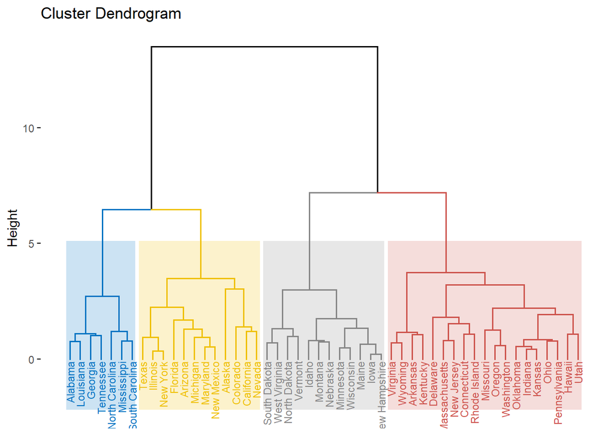

```r
# Visualize the tree
fviz_dend(hk, cex = 0.6, palette = "jco",
          rect = TRUE, rect_border = "jco", rect_fill = TRUE)
```

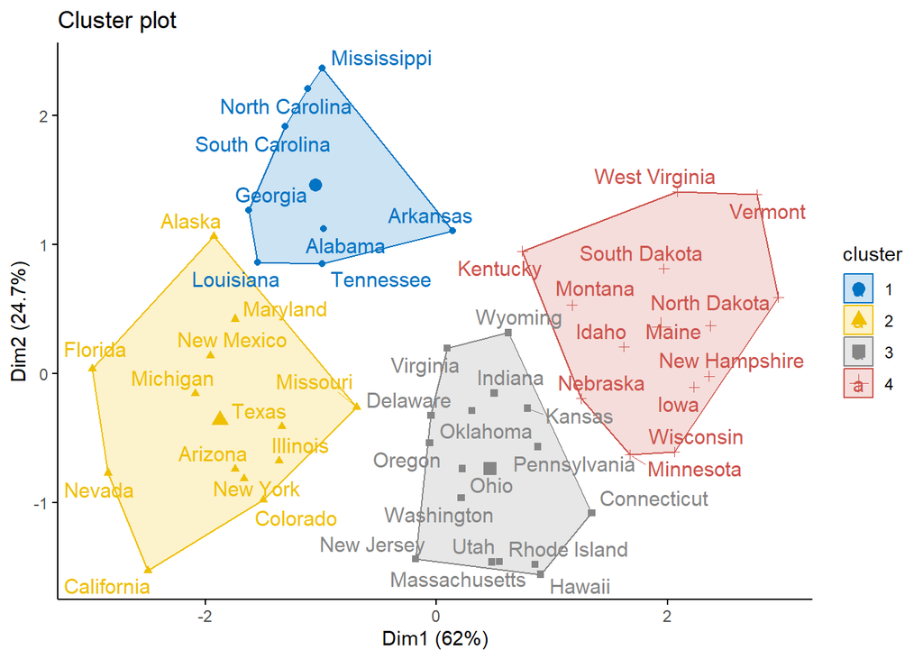

```r
# Visualize the hkmeans final clusters
fviz_cluster(hk, palette = "jco", repel = TRUE,
             ggtheme = theme_classic())
```

## 0.12 Fuzzy Clustering

The fuzzy clustering is considered as soft clustering, in which each element has a probability of belonging to each cluster. In other words, each element has a set of membership coefficients corresponding to the degree of being in a given cluster.

This is different from k-means and k-medoid clustering, where each object is affected exactly to one cluster. K-means and k-medoids clustering are known as hard or non-fuzzy clustering.

In fuzzy clustering, points close to the center of a cluster, may be in the cluster to a higher degree than points in the edge of a cluster. The degree, to which an element belongs to a given cluster, is a numerical value varying from 0 to 1.

The fuzzy c-means (FCM) algorithm is one of the most widely used fuzzy clustering algorithms. The centroid of a cluster is calculated as the mean of all points, weighted by their degree of belonging to the cluster.

For Clear understanding read this [document](https://drive.google.com/file/d/1RI_ZXtyUd4mz7LF33Z75fQ-e_aVepsNA/view?usp=sharing).

We’ll use the following R packages: 1) `cluster` for computing fuzzy clustering and 2) `factoextra` for visualizing clusters.

The function `fanny()` [`cluster` R package] can be used to compute fuzzy clustering. **FANNY** stands for fuzzy analysis clustering.

A simplified format is:

```r
fanny(x, k, metric = "euclidean", stand = FALSE)
```

```
-----------------------------------------------------------------------------------
x: A data matrix or data frame or dissimilarity matrix
-----------------------------------------------------------------------------------
k: The desired number of clusters to be generated
-----------------------------------------------------------------------------------
metric: Metric for calculating dissimilarities between observations
-----------------------------------------------------------------------------------
stand: If TRUE, variables are standardized before calculating the dissimilarities
-----------------------------------------------------------------------------------
```

Note that, there are more advanced clustering methods available like: [Model Based Clustering](https://bradleyboehmke.github.io/HOML/model-clustering.html), [DBSCAN: Density-Based Clustering](http://www.sthda.com/english/wiki/wiki.php?id_contents=7940).

## 0.13 Reference

1. *Bradley Boehmke & Brandon Greenwell*; [Hands-On Machine Learning with R](https://bradleyboehmke.github.io/HOML/)
2. Ester, Martin, Hans-Peter Kriegel, Jörg Sander, and Xiaowei Xu. 1996. “A Density-Based Algorithm for Discovering Clusters in Large Spatial Databases with Noise.” In, 226–31. AAAI Press.
3. Kaufman, Leonard, and Peter Rousseeuw. 1990. Finding Groups in Data: An Introduction to Cluster Analysis.